# Fitting Conditional and Simultaneous Autoregressive Spatial Models in hglm

### Ohio elementary school grades data set

We analyze a data set consisting of the student grades of 1,967 Ohio Elementary Schools during the year 2001–2002. The data set is freely available on the internet (URL http://www.spatial-econometrics.com/) as a web supplement to LeSage and Pace (2009) but was not analyzed therein. The shape files were downloaded from http://www.census.gov/cgi-bin/geo/shapefiles2013/main and the districts of 1,860 schools in these two files could be connected unambiguously. The data set contains information on, for instance, school building ID, Zip code of the location of the school, proportion of passing on five subjects, number of teachers, number of students, etc. We regress the median of 4th grade proficiency scores, $\mathbf{y}$, on an intercept, based on school districts. The statistical model is given as

$$\label{eq:7}
y_{i,j}=\mu + v_{j} + \epsilon_{i,j}, (\#eq:7)$$

where $i=1,2,\dots,1860$ (observations), $j=1,2,\dots,616$ (districts), $\epsilon_{i,j} \sim N \left( 0, \sigma_{e}^2\right)$, $\{ v_j \} =\mathbf{v} \sim N \left( \mathbf{0}, \tau \left( \mathbf{I} - \rho \mathbf{W}\right)^{-1} \right)$ and $\mathbf{W}= \{w_{p,q} \}_{p,q=1}^{616}$ is a spatial weight matrix (i.e., the neighborhood matrix). We construct $w_{p,q}=1$ if the two districts $p$ and $q$ are adjacent, and $w_{p,q}=0$ otherwise.

The above choice of constructing the weight matrix is rather simple. Because the aim of this paper is to demonstrate the use of *hglm* for fitting spatial models rather than drawing conclusions from real data analysis, we skip any further discussion on the construction of the weight matrix. Interested, readers are referred to LeSage and Pace (2009) for more discussion on the construction of the spatial weight matrices. With the spatial weight matrix defined as above, we can estimate model (@ref(eq:7)) by using our *hglm* package in the following way.

```r
> ## load the data object 'ohio'
> data(ohio)
>
> ## fit a CAR model for the median scores of the districts
> X <- model.matrix(MedianScore ~ 1, data = ohioMedian)
> Z <- model.matrix(~ 0 + district, data = ohioMedian)
> ohioCAR <- hglm(y = ohioMedian$MedianScore, X = X, Z = Z,
+                 rand.family = CAR(D = ohioDistrictDistMat))
> summary(ohioCAR)
```

```r
Call:
hglm.default(X = X, y = ohioMedian$MedianScore, Z = Z,
    rand.family = CAR(D = ohioDistrictDistMat))

----------
MEAN MODEL
----------

Summary of the fixed effects estimates:

            Estimate Std. Error t-value Pr(>|t|)
(Intercept)   72.429      0.819   88.44   <2e-16 ***
---
Signif. codes:  0 '***' 0.001 '**' 0.01 '*' 0.05 '.' 0.1 ' ' 1
Note: P-values are based on 1566 degrees of freedom

Summary of the random effects estimates:

     Estimate Std. Error
[1,]  -21.433     11.071
[2,]  -17.890     10.511
[3,]   -4.537      7.844
...
NOTE: to show all the random effects, use print(summary(hglm.object),
      print.ranef = TRUE).

----------------
DISPERSION MODEL
----------------

NOTE: h-likelihood estimates through EQL can be biased.

Dispersion parameter for the mean model:
[1] 190.5

Model estimates for the dispersion term:

Link = log

Effects:
  Estimate Std. Error
    5.2498     0.0357

Dispersion = 1 is used in Gamma model on deviances to calculate the
standard error(s).

Dispersion parameter for the random effects:
[1] 1.01

Dispersion model for the random effects:

Link = log

Effects:
.|Random1
                 Estimate Std. Error
1/CAR.tau          0.0097      8e-04
-CAR.rho/CAR.tau  -0.0011      2e-04
CAR.tau (estimated spatial variance component): 103.6
CAR.rho (estimated spatial correlation): 0.1089

Dispersion = 1 is used in Gamma model on deviances to calculate the
standard error(s).

EQL estimation converged in 5 iterations.
```

The estimated spatial correlation parameter among school districts is 0.109. We can obtain fitted values from the CAR model and predict the school districts without any observations. The following codes perform such prediction and the results are visualized in Figure 3(B). We remove the estimate of Lake Erie, as estimation for an uninhabited region is meaningless.

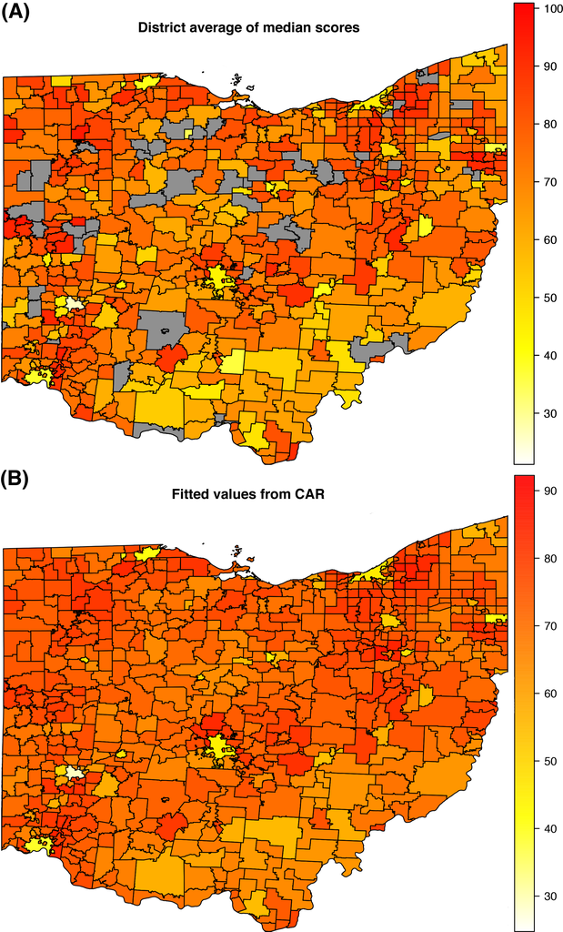

Figure 3: Observed (A) and predicted (B) median 4th grade proficiency scores of the school districts in Ohio. Districts without any observations are displayed in gray.

```r
> ## extract districts from the map data
> districtShape <- as.numeric(substr(as.character(ohioShape@data$UNSDIDFP), 3, 7))
>
> ## calculate fitted values from the CAR model
> CARfit <- matrix(ohioCAR$ranef + ohioCAR$fixef,
+                  dimnames = list(rownames(ohioDistrictDistMat), NULL))
> ohioShape@data$CAR <- CARfit[as.character(districtShape),]
> is.na(ohioShape@data$CAR[353]) <- TRUE  # remove estimate of Lake Erie
>
> ## visualize the results
> spplot(ohioShape, zcol = "CAR", main = "Fitted values from CAR",
+        col.regions = heat.colors(1000)[1000:1], cuts = 1000)
```

A `predict()` method is not available because predicting spatially correlated random effects for autoregressive models requires re-fitting the whole model. Thus standard kriging cannot be used because the covariance structure changes if the neighborhood matrix is altered, while keeping $\tau$ and $\rho$ unchanged. Instead, the fitted model needs to include the entire neighborhood matrix with districts having missing data as well. Consequently, the incidence matrix $\mathbf{Z}$ has more columns than rows. This method of predicting random effects is frequently used in animal breeding applications (Henderson 1984) but, to our knowledge, has not been applied to spatial autoregressive models previously.

In the example above, `ohioMedian$district` has 616 levels and 54 of the districts have no records (Figure 3(A)). The incidence matrix `Z`, created using the `model.matrix` function, therefore has 616 columns and 54 of these are columns of zeros. Hence, there are 616 levels in the fitted spatial random effect giving predictions for the districts without records.

# Conclusion

The *hglm* package is one of few non-Bayesian packages on CRAN to fit spatial HGLMs, where the fixed and random effects are estimated simultaneously. We have shown how the HGLM framework, allowing linear predictors to model variance components, can be exploited to fit CAR and SAR models. This gives a computationally efficient algorithm for moderately sized problems (number of locations $<$ approx. $5000$).

# Acknowledgement

X. Shen was supported by a Swedish Research Council grant (No. 2014-371).

Besag, J. 1974. “Spatial Interaction and the Statistical Analysis of Lattice Systems (with Discussion).” *Journal of the Royal Statistical Society, Series B* 36: 192–236.

Clayton, D., and J. Kaldor. 1987. “Empirical Bayes Estimation of Age-Standardized Relative Risk for Use in Disease Mapping.” *Biometrics* 43: 671–81.

Cressie, N. A. C. 1993. *Statistics for Spatial Data*. Revised. Wiley, New York.

He, Y., J. S. Hodges, and B. P. Carlin. 2007. “Re-Considering the Variance Parameterization in Multiple Precision Models.” *Bayesian Analysis* 2: 529–56.

Henderson, C. R. 1984. *Applications of Linear Models in Animal Breeding*. University of Guelph, Guelph, Ontario.

Hodges, J. S. 2013. *Richly Parametarized Linear Models: Additive Linear and Time Series and Spatial Models Using Random Effects*. Chapman; Hall/CRC, Boca Raton.

Lee, W., and Y. Lee. 2012. “Modifications of REML Algorithm for HGLMs.” *Statistics and Computing* 22: 959–66.

Lee, Y., and J. A. Nelder. 1996. “Hierarchical Generalized Linear Models (with Discussion).” *Journal of the Royal Statistical Society, Series B* 58: 619–78.

———. 2001. “Hierarchical Generalised Linear Models: A Synthesis of Generalised Linear Models, Random Effect Models and Structured Dispersions.” *Biometrika* 88: 987–1006.

———. 2003. “Extended-REML Estimators.” *Journal of Applied Statistics* 30: 845–46.

Lee, Y., J. A. Nelder, and Y. Pawitan. 2006. *Generalized Linear Models with Random Effects: Unified Analysis via h-Likelihood*. Chapman & Hall/CRC, Boca Raton.

LeSage, J., and R. Pace. 2009. *Introduction to Spatial Econometrics*. Chapman & Hall/CRC, Boca Raton.

Lindgren, F., and H. Rue. 2015. “Bayesian Spatial Modelling with R-INLA.” *Journal of Statistical Software* 63 (19): 1–25. http://www.jstatsoft.org/v63/i19.

Lunn, D. J., J. A. Thomas, N. Best, and D. Spiegelhalter. 2000. “WinBUGS – a Bayesian Modelling Framework: Concepts, Structure, and Extensibility.” *Statistics and Computing* 10: 325–37.

Martins, T. G., D. Simpson, F. Lindgren, and H. Rue. 2013. “Bayesian Computing with INLA: New Features.” *Computational Statistics & Data Analysis* 67: 68–83.

Molas, Marek, and Emmanuel Lesaffre. 2011. “Hierarchical Generalized Linear Models: The R Package HGLMMM.” *Journal of Statistical Software* 39 (13): 1–20. http://www.jstatsoft.org/v39/i13.

Newcomb, R. 1969. “On the Simultaneous Diagonalization of Two Semi-Definite Matrices.” *Quarterly of Applied Mathematics* 19: 144–46.

Noh, Maengseok, and Youngjo Lee. 2007. “REML Estimation for Binary Data in GLMMs.” *Journal of Multivariate Analysis* 98: 896–915.

Ord, K. 1975. “Estimation Methods for Models of Spatial Interaction.” *Journal of the American Statistical Association* 70: 120–26.

Rönnegård, L., X. Shen, and M. Alam. 2010. “Hglm: A Package for Fitting Hierarchical Generalized Linear Models.” *The R Journal* 2 (2): 20–28.

Rousset, F., and Jean-Baptiste Ferdy. 2014. “Testing Environmental and Genetic Effects in the Presence of Spatial Autocorrelation.” *Ecography* 37 (8): 781–90.

Wall, Melanie M. 2004. “A Close Look at the Spatial Structure Implied by the CAR and SAR Models.” *Journal of Statistical Planning and Inference* 121: 311–24.